# Модуль 1. Базовий. Лабораторна робота №1. Створення основи типового Data Science-проєкту

© [Сидоренко В. М.](https://www.linkedin.com/in/valeriy-sydorenko-6782279a/), 2025

2025-09-19

**Мета:** *“Швидкий старт” для створення бази Data Science-проекту у середовищі RStudio із застосуванням концепції “грамотного програмування” засобами мови програмування R, пакету RMarkdown та системи комп’ютерної верстки LaTeX*.

## Що ви будете вміти?

- виконувати експорт/імпорт даних, елеменарну їх обробку, візуалізацію даних та результатів обчислень засобами мови R у середовищі IDE RStudio.
- Створювати електронний документ (у форматах html, pdf, doc) на кшталт того, **який ви зараз читаєте** (інтерактивне меню, можливість показати/сховати код і т. ін.).
- використовувати засоби редактору LaTeX для набору формул, наприклад, як ця: $y(x)=b_0+b_1x+b_2x^2$.
- створювати бібліографічну базу даних засобами BibTeX, яка автоматично формує розділ посилань ‘References’, як **у цьому документі**.

## Короткі теоретичні відомості

### Що таке Data Science-проект?

Будь-який Data Science-проект (альтернативна назва – Data Mining-проект) має на меті реалізацію на практиці методології [CRISP DM](https://www.the-modeling-agency.com/crisp-dm.pdf) (wikipedia 2018). Згідно з стандартом CRISP-DM 1.0 життєвий цикл проекту Data Mining має складатися з шести фаз (рис. 1):  
- розуміння бізнес-процесів (business understanding);  
- розуміння даних (data understanding);  
- підготовка даних (data preparation);  
- моделювання (modeling);  
- оцінка (evaluation);  
- розміщення (deployment).

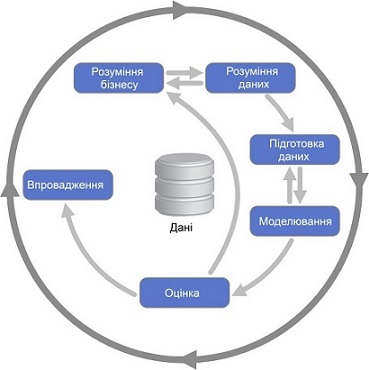

*Рис. 1. Життєвий цикл процесу Data Mining згідно з методологією CRISP*

**Фаза розуміння** бізнес-процесів включає наступні задачі:  
- визначення бізнес-цілей;  
- визначення ситуації;  
- визначення цілей Data Mining;  
- створення плану проекта.  
**Фаза розуміння** даних включає наступні задачі:  
- первинний збір даних;  
- опис даних;  
- вивчення даних;  
- перевірка якості даних.  
**Фаза підготовки** даних включає в себе всі дії, пов’язані з остаточним формуванням набору даних для аналізу. При цьому виконуються п’ять задач:  
- вибір даних;  
- очищення даних;  
- конструювання даних;  
- інтеграція даних;  
- форматування даних.  
**Фаза моделювання** -– призначена для вибору оптимального методу побудови моделей і настроювання його параметрів для отримання оптимальних рішень. На даній фазі вирішуються наступні задачі:  
- вибір методу моделювання;  
- генерація тестового проекту;  
- створення моделей;  
- оцінка моделей.  
**Фаза оцінки** -– призвана більш ґрунтовно оцінити модель до процесу її остаточного розміщення, щоб впевнитись у досяжності поставлених бізнес-цілей. Дана фаза включає наступні задачі:  
- оцінка результатів;  
- перегляд процесу;  
- визначення подальших дій.  
**Фаза розміщення** передбачає розгортання моделі.

Якщо виділити з даного процесу суто технологічну складову, то типова технологічна основа будь-якого Data Science-проекту має виглядати наступним чином (Garrett Grolemund 2018) (рис. 2).

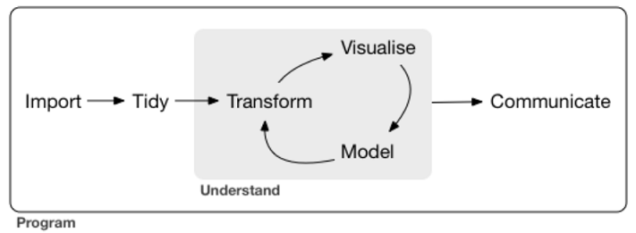

*Рис. 2. Структура типового Data Science-проекту*

Перша задача *імпорту даних* (**Import**) полягає у вилученні необхідних сирих даних з будь-яких джерел (файли, БД, дані з датчиків у реальному часі і т. ін) самого різного формату.  
Друга задача (**Tidy**) – *приведення даних до* так званого *“охайного” вигляду*, придатного для аналізу. Як правило мова йде про приведення даних до табличного вигляду “ключ-значення”, або, іншими словами, “об’єкт-ознака”. Дана процедура є частиною більш загальної задачі підготовки даних до аналізу (**Wrangling, Munging**), яка включає інші процедури, наприклад, заповнення пропущених значень (Missing Value Emputation), вилучення неінформативних даних (data reduction), різного роду трансформації (**Transforming**) і т. ін. Тобто, **Tiding+Transforming=Wrangling(Munging)**.  
Тріада задач *трансформація-візуалізація-моделювання* (**Transform-Visualise-Model**) складають ядро Data Mining-процесу, суть якого полягає в пошуку нетривіальних практично корисних закономірностей в даних, шляхом висування і перевірки гіпотез, побудови різного роду моделей, який обов’язково супроводжується візуалізацією як проміжних, так і кінцевих результатів моделювання, що предоставляються замовнику. Саме ця тріада задач забезпечує фази розуміння (**Understanding**) даних, моделей та паттернів, що знаходяться в даних і створюють основу монетизованого продукту інтелектуального аналізу даних.  
Останній етап – представлення проміжних чи остаточних результатів інтелектуального аналізу даних (**Сommunicate**) іншим членам команди, які задіяні у проекті, у зручному для сприйняття вигляді з використанням прози, таблиць, графіків та коду.  
Для реалізації типового Data Science-проекту необхідний відповідний інструментарій, який би був гнучким і задовольняв всім необхідним вимогам, котрих потребують вищезгадані задачі, і давав би можливість розв’язати будь-яку задачу без значних витрат часу, в першу чергу, на маніпулювання даними та підготовку результатів.  
Мова і середовище програмування R з великим арсеналом програмних пакетів, IDE RStudio та технологія так званого *грамотного програмування* дозволяє ефективну реалізацію всіх етапів типового Data Science-проекту, об’єднавши всі задачі в єдине ціле.

### Концепція грамотного програмування

Представлення проміжних чи остаточних результатів проекту може бути виконано у тому чи іншому вигляді – звіту, презентації, методичних вказівок, наукової статті тощо, в одному з поширених форматів – .doc, pdf, .html тощо.

Протягом багатьох років у наукових та ділових колах стандартом де-факто є застосування так званої парадигми [*грамотного програмування*](https://en.wikipedia.org/wiki/Literate_programming) для підготовки електронних документів з використанням у тому числі і потужніх засобів комп’ютерної графіки. З виникненням і розвитком Data Science, методологію грамотного програмування було взято на озброєння і реалізоване практично в кожному потужному інструменті Data Science.

*Грамотне програмування* (Literate Programming) – концепція, методологія програмування і документування, в якій програма складається з прози на природній мові упереміж з макропідстановками і кодом на мовах програмування.

В основі технології грамотного програмування лежить поняття *динамічного документу* – текстового документу, який складається з тексту та коду, з використанням необхідних мов програмування, який дозволяє згенерувати власне електронний документ заданого формату. При цьому використовуються як можливості мов розмітки документів (напр. Markdown, YAML, HTML, LaTeX), так і можливості доступу до потужних програмних бібліотек, призначених для обробки даних та комп’ютерної графіки.

Таким чином, логічно мати певне програмне середовище, яке дозволить поєднати низку таких технологій разом і створити зручний інтерфейс розробника. Існують різні програмні засоби і середовища [(IDE, Integrated Development Environment, інтегроване середовище розробки)](https://uk.wikipedia.org/wiki/%D0%86%D0%BD%D1%82%D0%B5%D0%B3%D1%80%D0%BE%D0%B2%D0%B0%D0%BD%D0%B5_%D1%81%D0%B5%D1%80%D0%B5%D0%B4%D0%BE%D0%B2%D0%B8%D1%89%D0%B5_%D1%80%D0%BE%D0%B7%D1%80%D0%BE%D0%B1%D0%BA%D0%B8), що дозволяють реалізувати технологію грамотного програмування.

У даній лабораторній роботі пропонується низка наразі актуальних і популярних інструментів для створення динамічних документів (рис. 3):

- IDE [R Studio](https://www.rstudio.com/) як інтегроване середовище розробки;
- спеціалізовану мову програмування [R](https://cran.r-project.org/) та арсенал її потужніх бібліотек – для маніпулювання даними та візуалізації результатів;
- фреймворк [RMarkdown](http://rmarkdown.rstudio.com/) – для підготовки динамічних звітів мовою розмітки Markdown; (див.(sandino 2013) та шпаргалку у RStudio: *“Help\Cheat_Sheets”*); також покрокове керівництво [Д. Омельченко](https://rpubs.com/domelia/828777); також див. [R Markdown: продолжение. Подготовка рукописи научной статьи](https://rpubs.com/domelia/834925);
- мову розмітки даних [LaTex](https://uk.wikipedia.org/wiki/LaTeX) для високоякісного оформлення наукових документів.

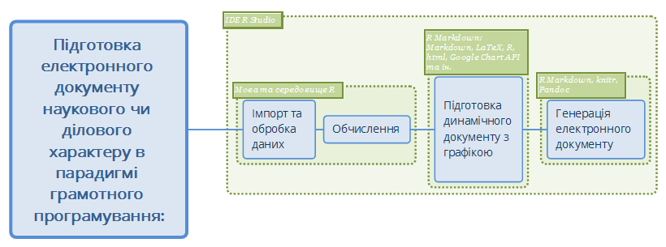

*Рис. 3. Структура процесу підготовки електронного документу наукового чи ділового характеру в парадигмі грамотного програмування (literate programming)*

### Markdown і RMarkdown

**Markdown** (МФА: [маркдаун]) – полегшена мова розмітки даних, яку створено з ухилом на прочитність та зручність у публікації з подальшим перетворенням її на structurally valid XHTML або HTML.

Такі сайти, як GitHub, Reddit та Stack Overflow використовують Markdown для полегшення обговорень між користувачами.

**R Markdown** (Yihui Xie 2018) – фреймворк R, який дозволяє створювати динамічні Markdown-документи у середовищі IDE RStudio в стилі грамотного програмування з використанням всіх можливих потужностей мови R та її бібліотек. Дозволяє реалізовувати інтерфейс так званих ноутбуків для створення документів з текстом та кодом разом для виготовлення елегантно відформатованого виводу. Дозволяє використовувати декілька мов, включаючи R, Python, С++, HTML, SQL, [Stan](http://mc-stan.org/). Через конвертор [Pandoc](http://pandoc.org/) дозволяє здійснювати вивід у html, doc або pdf формат у вигляді веб-сторінок, брошюр, буклетів, слайдів.

### Інсталяція R

Для цього необхідно зайти на [CRAN](https://cran.r-project.org/), скачати і встановити актуальну версію R. Даний дистрибутив R має свій GUI, однак його можливості досить обмежені. Тут, у розділі ‘Contributed’, також можна знайти безліч цікавої літератури, написаної різними мовами.  
Одне з найкоротших і доступних введень у мову R можна знайти на сторінці [Дмитра Храмова](http://dkhramov.dp.ua/Comp.R.html#.Wpetc1rFJdj). Зокрема, знайомство з [елементами базової графіки](http://dkhramov.dp.ua/images/edu/Stu.WebMining/ch04_graphics.pdf).

### Інсталяція RStudio

Для зручної роботи і відладки програм, зокрема роботи з фреймворком RMarkdown для створення динамічного документу, необхідно встановити IDE [RStudio](https://www.rstudio.com/products/rstudio/download/).

### Створення RMarkdown-документу

1. Завантажити RStudio.
2. Створити RMarkdown-документ у форматі [R Notebook](http://rmarkdown.rstudio.com/r_notebooks.html), вибравши відповідний пункт [меню](https://prnt.sc/gkpes4).

### Генерація електронного документу

Генерація електронного документу здійснюється натисканням комбінації *Ctrl+Alt+K*.

## Приклад створення Markdown-документу

### Виконання завдання

1. Створюємо документ R Markdown, як описано вище у п. *Створення RMarkdown-документу*.
2. Налаштовуємо потрібним чином YAML-заголовок документу, у якому задаються метадані всього документу (рис. 4).

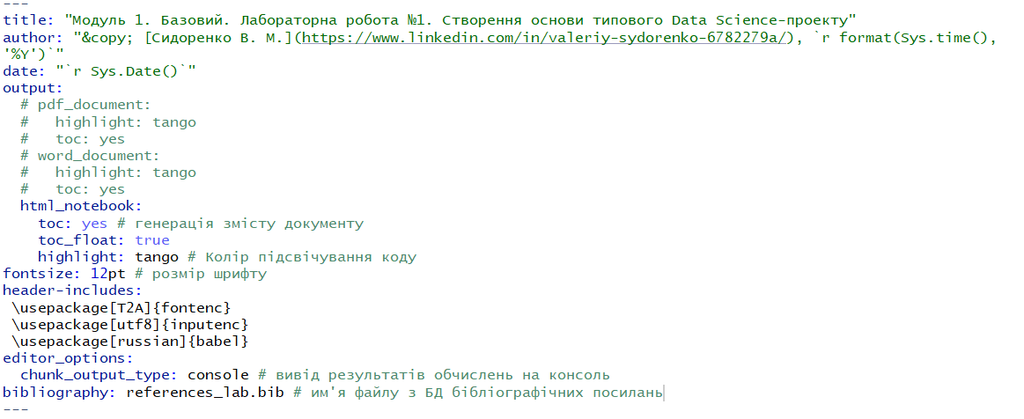

*Рис. 4. Вигляд YAML-заголовку для документу, який ви зараз читаєте*

3. Пишемо код на R засобами базової графіки у відповідній зоні, яка називається чанком:

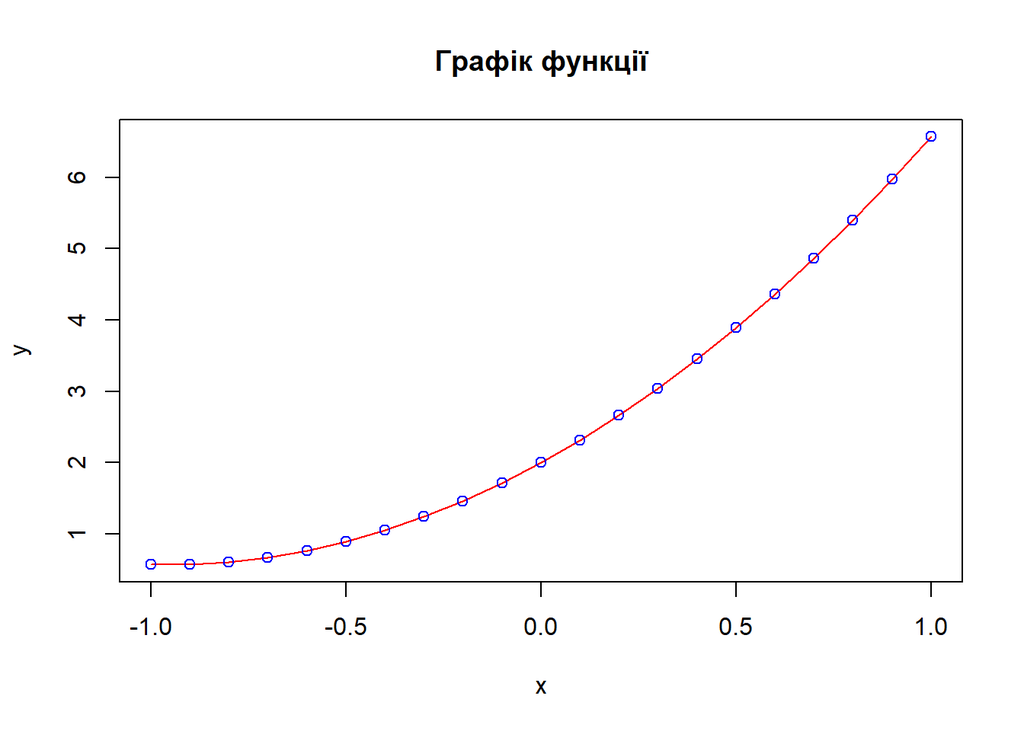

```r
# Задаємо параметри функції
b0 <- 2
b1 <- 3
b2 <- 1.57

# Задаємо область визначення

x <- seq(-1, 1, .1)
y <- b0 + b1 * x + b2 * x^2

plot(x, y,
     type = "l",
     col = "red",
     main = "Графік функції",
     xlab = "x",
     ylab = "y"
     )
points(x, y,
       col = "blue")
```

```r
df <- data.frame(x = x, y = y) # створюємо таблицю даних
```

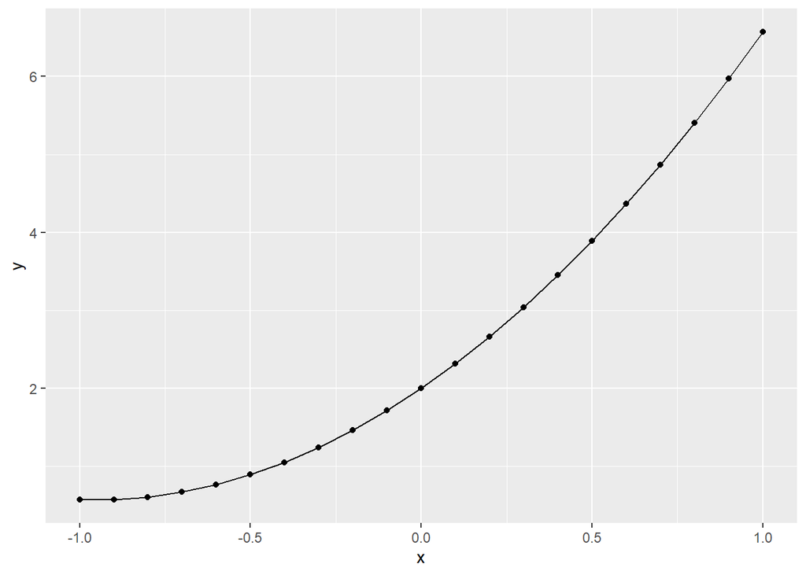

```r
library(dplyr)
library(ggplot2)


df |>
  ggplot(aes(x = x, y = y)) +
  geom_line() +
  geom_point()
```

4. Продемонструємо можливості пакету `rio` (Chan et al. 2018) для експорту (імпорту) даних на диск (з диску).

```r
# install.packages("rio") # інсталяція пакету
library(rio) # підключення пакету
export(df, "data/data.csv")
```

5. Виконуємо імпорт даних із файлу і візуалізацію у вигляді таблиці.

```r
dfNew <-  import("data/data.csv")

# Таблиця засобами knitr
knitr::kable(head(dfNew),
             caption = "_Табл. 1. Фрагмент таблиці даних_")
```

*Табл. 1. Фрагмент таблиці даних*

| x | y |
| --- | --- |
| -1.0 | 0.5700 |
| -0.9 | 0.5717 |
| -0.8 | 0.6048 |
| -0.7 | 0.6693 |
| -0.6 | 0.7652 |
| -0.5 | 0.8925 |

```r
DT::datatable(dfNew)
```

|  | x | y |
| --- | --- | --- |
| 1 | -1 | 0.57 |
| 2 | -0.9 | 0.5717 |
| 3 | -0.8 | 0.6048 |
| 4 | -0.7 | 0.6693 |
| 5 | -0.6 | 0.7652 |
| 6 | -0.5 | 0.8925 |
| 7 | -0.4 | 1.0512 |
| 8 | -0.3 | 1.2413 |
| 9 | -0.2 | 1.4628 |
| 10 | -0.1 | 1.7157 |

[output cut: 11 more lines]

```r
# Таблиця засобами stargazer
# stargazer::stargazer(head(dfNew),
#                      type = "html",
#                      summary = FALSE,
#              title = "_Табл. 1. Фрагмент таблиці даних_")


# Таблиця засобами xtable
# print(xtable::xtable(head(dfNew),
#                      type = "html",
#                      html.table.attributes="border=0",
#                      summary = FALSE,
#              caption = "_Табл. 1. Фрагмент таблиці даних_"))
```

6. Формуємо результуючу таблицю.

*Табл. 2. Параметри функції*

| Параметр | Значення |
| --- | --- |
| $b_0$ | 2 |
| $b_1$ | 3 |
| $b_2$ | 1.57 |
| $x_1$ | -1 |
| $x_2$ | 1 |

**Зауваження.**[^1]

### Індивідуальні завдання на лабораторну роботу

Видає викладач.

### Домашнє завдання

1. Ознайомитися з можливостями пакету `ggplot2` (Wickham 2009).
2. Оптимізувати код, наведений у даній методичці, за допомогою потокового оператора `%>%` засобами пакету `ggplot2`.
3. Побудувати графік функції засобами пакету `ggplot2`. (Fortmann-Roe 2015)

(Garrett Grolemund 2018)

## References

Chan, Chung-hong, Geoffrey CH Chan, Thomas J. Leeper, and Jason Becker. 2018. *Rio: A Swiss-Army Knife for Data File i/o*.

Fortmann-Roe, Scott. 2015. “Consistent and Clear Reporting of Results from Diverse Modeling Techniques: The A3 Method.” *Journal of Statistical Software* 66 (7): 1–23. http://www.jstatsoft.org/v66/i07/.

Garrett Grolemund, Hadley Wickham. 2018. *R for Data Science*. http://r4ds.had.co.nz/index.html.

sandino. 2013. “Cheat Sheet of Markdown.” Article. https://github.com/sandino/Markdown-Cheatsheet#emphasis.

Wickham, Hadley. 2009. *Ggplot2: Elegant Graphics for Data Analysis*. Springer-Verlag New York. https://ggplot2-book.org/.

wikipedia. 2018. “Cross-Industry Standard Process for Data Mining.” Article. https://en.wikipedia.org/wiki/Cross-industry_standard_process_for_data_mining.

Yihui Xie, Garrett Grolemund, J. J. Allaire. 2018. *R Markdown: The Definitive Guide*. https://bookdown.org/yihui/rmarkdown/.

[^1]: .Rmd файл для генерації **цого документу** знаходиться тут